# Risk Factor Analysis

## Outcome Variable

**Outcome Variable:** pers_wast

## Predictor Variables

**Intervention Variable:** mhtcm

**Adjustment Set:**

- arm
- W_mage
- meducyrs
- feducyrs
- single
- delta_W_mage
- delta_meducyrs
- delta_feducyrs
- delta_single

## Stratifying Variables

The analysis was stratified on these variable(s):

- agecat
- studyid
- country

## Data Summary

| agecat | studyid | country | mhtcm | pers_wast | n_cell | n |
| --- | --- | --- | --- | --- | --- | --- |
| 0-24 months | ki0047075b-MAL-ED | BANGLADESH | >=155 cm | 0 | 21 | 248 |
| 0-24 months | ki0047075b-MAL-ED | BANGLADESH | >=155 cm | 1 | 3 | 248 |
| 0-24 months | ki0047075b-MAL-ED | BANGLADESH | <151 cm | 0 | 154 | 248 |
| 0-24 months | ki0047075b-MAL-ED | BANGLADESH | <151 cm | 1 | 7 | 248 |
| 0-24 months | ki0047075b-MAL-ED | BANGLADESH | [151-155) cm | 0 | 60 | 248 |
| 0-24 months | ki0047075b-MAL-ED | BANGLADESH | [151-155) cm | 1 | 3 | 248 |
| 0-24 months | ki0047075b-MAL-ED | BRAZIL | >=155 cm | 0 | 124 | 217 |
| 0-24 months | ki0047075b-MAL-ED | BRAZIL | >=155 cm | 1 | 2 | 217 |
| 0-24 months | ki0047075b-MAL-ED | BRAZIL | <151 cm | 0 | 52 | 217 |
| 0-24 months | ki0047075b-MAL-ED | BRAZIL | <151 cm | 1 | 0 | 217 |
| 0-24 months | ki0047075b-MAL-ED | BRAZIL | [151-155) cm | 0 | 39 | 217 |
| 0-24 months | ki0047075b-MAL-ED | BRAZIL | [151-155) cm | 1 | 0 | 217 |
| 0-24 months | ki0047075b-MAL-ED | INDIA | >=155 cm | 0 | 53 | 240 |
| 0-24 months | ki0047075b-MAL-ED | INDIA | >=155 cm | 1 | 2 | 240 |
| 0-24 months | ki0047075b-MAL-ED | INDIA | <151 cm | 0 | 102 | 240 |
| 0-24 months | ki0047075b-MAL-ED | INDIA | <151 cm | 1 | 13 | 240 |
| 0-24 months | ki0047075b-MAL-ED | INDIA | [151-155) cm | 0 | 64 | 240 |
| 0-24 months | ki0047075b-MAL-ED | INDIA | [151-155) cm | 1 | 6 | 240 |
| 0-24 months | ki0047075b-MAL-ED | NEPAL | >=155 cm | 0 | 41 | 238 |
| 0-24 months | ki0047075b-MAL-ED | NEPAL | >=155 cm | 1 | 0 | 238 |
| 0-24 months | ki0047075b-MAL-ED | NEPAL | <151 cm | 0 | 131 | 238 |
| 0-24 months | ki0047075b-MAL-ED | NEPAL | <151 cm | 1 | 2 | 238 |
| 0-24 months | ki0047075b-MAL-ED | NEPAL | [151-155) cm | 0 | 62 | 238 |
| 0-24 months | ki0047075b-MAL-ED | NEPAL | [151-155) cm | 1 | 2 | 238 |
| 0-24 months | ki0047075b-MAL-ED | PERU | >=155 cm | 0 | 58 | 283 |
| 0-24 months | ki0047075b-MAL-ED | PERU | >=155 cm | 1 | 0 | 283 |
| 0-24 months | ki0047075b-MAL-ED | PERU | <151 cm | 0 | 165 | 283 |
| 0-24 months | ki0047075b-MAL-ED | PERU | <151 cm | 1 | 0 | 283 |
| 0-24 months | ki0047075b-MAL-ED | PERU | [151-155) cm | 0 | 59 | 283 |
| 0-24 months | ki0047075b-MAL-ED | PERU | [151-155) cm | 1 | 1 | 283 |

[output cut: 342 more lines]

The following strata were considered:

- agecat: 0-24 months, studyid: ki0047075b-MAL-ED, country: BANGLADESH
- agecat: 0-24 months, studyid: ki0047075b-MAL-ED, country: BRAZIL
- agecat: 0-24 months, studyid: ki0047075b-MAL-ED, country: INDIA
- agecat: 0-24 months, studyid: ki0047075b-MAL-ED, country: NEPAL
- agecat: 0-24 months, studyid: ki0047075b-MAL-ED, country: PERU
- agecat: 0-24 months, studyid: ki0047075b-MAL-ED, country: SOUTH AFRICA
- agecat: 0-24 months, studyid: ki0047075b-MAL-ED, country: TANZANIA, UNITED REPUBLIC OF
- agecat: 0-24 months, studyid: ki1000304b-SAS-CompFeed, country: INDIA
- agecat: 0-24 months, studyid: ki1000304b-SAS-FoodSuppl, country: INDIA
- agecat: 0-24 months, studyid: ki1017093-NIH-Birth, country: BANGLADESH
- agecat: 0-24 months, studyid: ki1017093b-PROVIDE, country: BANGLADESH
- agecat: 0-24 months, studyid: ki1017093c-NIH-Crypto, country: BANGLADESH
- agecat: 0-24 months, studyid: ki1066203-TanzaniaChild2, country: TANZANIA, UNITED REPUBLIC OF
- agecat: 0-24 months, studyid: ki1101329-Keneba, country: GAMBIA
- agecat: 0-24 months, studyid: ki1112895-Guatemala BSC, country: GUATEMALA
- agecat: 0-24 months, studyid: ki1112895-iLiNS-Zinc, country: BURKINA FASO
- agecat: 0-24 months, studyid: ki1119695-PROBIT, country: BELARUS
- agecat: 0-24 months, studyid: ki1126311-ZVITAMBO, country: ZIMBABWE
- agecat: 0-24 months, studyid: ki1135781-COHORTS, country: GUATEMALA
- agecat: 0-24 months, studyid: ki1135781-COHORTS, country: INDIA
- agecat: 0-24 months, studyid: ki1135781-COHORTS, country: PHILIPPINES
- agecat: 0-24 months, studyid: ki1148112-LCNI-5, country: MALAWI
- agecat: 0-24 months, studyid: kiGH5241-JiVitA-3, country: BANGLADESH
- agecat: 0-6 months, studyid: ki0047075b-MAL-ED, country: BANGLADESH
- agecat: 0-6 months, studyid: ki0047075b-MAL-ED, country: BRAZIL
- agecat: 0-6 months, studyid: ki0047075b-MAL-ED, country: INDIA
- agecat: 0-6 months, studyid: ki0047075b-MAL-ED, country: NEPAL
- agecat: 0-6 months, studyid: ki0047075b-MAL-ED, country: PERU
- agecat: 0-6 months, studyid: ki0047075b-MAL-ED, country: SOUTH AFRICA
- agecat: 0-6 months, studyid: ki0047075b-MAL-ED, country: TANZANIA, UNITED REPUBLIC OF
- agecat: 0-6 months, studyid: ki1017093-NIH-Birth, country: BANGLADESH
- agecat: 0-6 months, studyid: ki1017093b-PROVIDE, country: BANGLADESH
- agecat: 0-6 months, studyid: ki1017093c-NIH-Crypto, country: BANGLADESH
- agecat: 0-6 months, studyid: ki1066203-TanzaniaChild2, country: TANZANIA, UNITED REPUBLIC OF
- agecat: 0-6 months, studyid: ki1101329-Keneba, country: GAMBIA
- agecat: 0-6 months, studyid: ki1119695-PROBIT, country: BELARUS
- agecat: 0-6 months, studyid: ki1126311-ZVITAMBO, country: ZIMBABWE
- agecat: 0-6 months, studyid: ki1135781-COHORTS, country: PHILIPPINES
- agecat: 0-6 months, studyid: kiGH5241-JiVitA-3, country: BANGLADESH
- agecat: 6-24 months, studyid: ki0047075b-MAL-ED, country: BANGLADESH
- agecat: 6-24 months, studyid: ki0047075b-MAL-ED, country: BRAZIL
- agecat: 6-24 months, studyid: ki0047075b-MAL-ED, country: INDIA
- agecat: 6-24 months, studyid: ki0047075b-MAL-ED, country: NEPAL
- agecat: 6-24 months, studyid: ki0047075b-MAL-ED, country: PERU
- agecat: 6-24 months, studyid: ki0047075b-MAL-ED, country: SOUTH AFRICA
- agecat: 6-24 months, studyid: ki0047075b-MAL-ED, country: TANZANIA, UNITED REPUBLIC OF
- agecat: 6-24 months, studyid: ki1000304b-SAS-CompFeed, country: INDIA
- agecat: 6-24 months, studyid: ki1000304b-SAS-FoodSuppl, country: INDIA
- agecat: 6-24 months, studyid: ki1017093-NIH-Birth, country: BANGLADESH
- agecat: 6-24 months, studyid: ki1017093b-PROVIDE, country: BANGLADESH
- agecat: 6-24 months, studyid: ki1017093c-NIH-Crypto, country: BANGLADESH
- agecat: 6-24 months, studyid: ki1066203-TanzaniaChild2, country: TANZANIA, UNITED REPUBLIC OF
- agecat: 6-24 months, studyid: ki1101329-Keneba, country: GAMBIA
- agecat: 6-24 months, studyid: ki1112895-Guatemala BSC, country: GUATEMALA
- agecat: 6-24 months, studyid: ki1112895-iLiNS-Zinc, country: BURKINA FASO
- agecat: 6-24 months, studyid: ki1119695-PROBIT, country: BELARUS
- agecat: 6-24 months, studyid: ki1126311-ZVITAMBO, country: ZIMBABWE
- agecat: 6-24 months, studyid: ki1135781-COHORTS, country: GUATEMALA
- agecat: 6-24 months, studyid: ki1135781-COHORTS, country: INDIA
- agecat: 6-24 months, studyid: ki1135781-COHORTS, country: PHILIPPINES
- agecat: 6-24 months, studyid: ki1148112-LCNI-5, country: MALAWI
- agecat: 6-24 months, studyid: kiGH5241-JiVitA-3, country: BANGLADESH

### Dropped Strata

Some strata were dropped due to rare outcomes:

- agecat: 0-24 months, studyid: ki0047075b-MAL-ED, country: BANGLADESH
- agecat: 0-24 months, studyid: ki0047075b-MAL-ED, country: BRAZIL
- agecat: 0-24 months, studyid: ki0047075b-MAL-ED, country: INDIA
- agecat: 0-24 months, studyid: ki0047075b-MAL-ED, country: NEPAL
- agecat: 0-24 months, studyid: ki0047075b-MAL-ED, country: PERU
- agecat: 0-24 months, studyid: ki0047075b-MAL-ED, country: SOUTH AFRICA
- agecat: 0-24 months, studyid: ki0047075b-MAL-ED, country: TANZANIA, UNITED REPUBLIC OF
- agecat: 0-24 months, studyid: ki1017093c-NIH-Crypto, country: BANGLADESH
- agecat: 0-24 months, studyid: ki1112895-Guatemala BSC, country: GUATEMALA
- agecat: 0-24 months, studyid: ki1119695-PROBIT, country: BELARUS
- agecat: 0-24 months, studyid: ki1148112-LCNI-5, country: MALAWI
- agecat: 0-6 months, studyid: ki0047075b-MAL-ED, country: BANGLADESH
- agecat: 0-6 months, studyid: ki0047075b-MAL-ED, country: BRAZIL
- agecat: 0-6 months, studyid: ki0047075b-MAL-ED, country: INDIA
- agecat: 0-6 months, studyid: ki0047075b-MAL-ED, country: NEPAL
- agecat: 0-6 months, studyid: ki0047075b-MAL-ED, country: PERU
- agecat: 0-6 months, studyid: ki0047075b-MAL-ED, country: SOUTH AFRICA
- agecat: 0-6 months, studyid: ki0047075b-MAL-ED, country: TANZANIA, UNITED REPUBLIC OF
- agecat: 0-6 months, studyid: ki1017093-NIH-Birth, country: BANGLADESH
- agecat: 0-6 months, studyid: ki1017093b-PROVIDE, country: BANGLADESH
- agecat: 0-6 months, studyid: ki1017093c-NIH-Crypto, country: BANGLADESH
- agecat: 0-6 months, studyid: ki1101329-Keneba, country: GAMBIA
- agecat: 0-6 months, studyid: ki1126311-ZVITAMBO, country: ZIMBABWE
- agecat: 0-6 months, studyid: kiGH5241-JiVitA-3, country: BANGLADESH
- agecat: 6-24 months, studyid: ki0047075b-MAL-ED, country: BANGLADESH
- agecat: 6-24 months, studyid: ki0047075b-MAL-ED, country: BRAZIL
- agecat: 6-24 months, studyid: ki0047075b-MAL-ED, country: INDIA
- agecat: 6-24 months, studyid: ki0047075b-MAL-ED, country: NEPAL
- agecat: 6-24 months, studyid: ki0047075b-MAL-ED, country: PERU
- agecat: 6-24 months, studyid: ki0047075b-MAL-ED, country: SOUTH AFRICA
- agecat: 6-24 months, studyid: ki0047075b-MAL-ED, country: TANZANIA, UNITED REPUBLIC OF
- agecat: 6-24 months, studyid: ki1017093c-NIH-Crypto, country: BANGLADESH
- agecat: 6-24 months, studyid: ki1112895-Guatemala BSC, country: GUATEMALA
- agecat: 6-24 months, studyid: ki1119695-PROBIT, country: BELARUS
- agecat: 6-24 months, studyid: ki1148112-LCNI-5, country: MALAWI

## Methods Detail

We’re interested in the causal parameters $E[Y_a]$ for all values of $a \in \mathcal{A}$. These parameters represent the mean outcome if, possibly contrary to fact, we intervened to set all units to have $A=a$. Under the randomization and positivity assumptions, these are identified by the statistical parameters $\psi_a=E_W[E_{Y|A,W}(Y|A=a,W)]$. In addition, we’re interested in the mean of $Y$, $E[Y]$ under no intervention (the observed mean). We will estimate these parameters by using SuperLearner to fit the relevant likelihood factors – $E_{Y|A,W}(Y|A=a,W)$ and $p(A=a|W)$, and then updating our likelihood fit using a joint TMLE.

For unadjusted analyses ($W=\{\}$), initial likelihoods were estimated using Lrnr_glm to estimate the simple $E(Y|A)$ and Lrnr_mean to estimate $p(A)$. For adjusted analyses, a small library containing Lrnr_glmnet, Lrnr_xgboost, and Lrnr_mean was used.

Having estimated these parameters, we will then use the delta method to estimate relative risks and attributable risks relative to a prespecified baseline level of $A$.

# Results Detail

## Results Plots

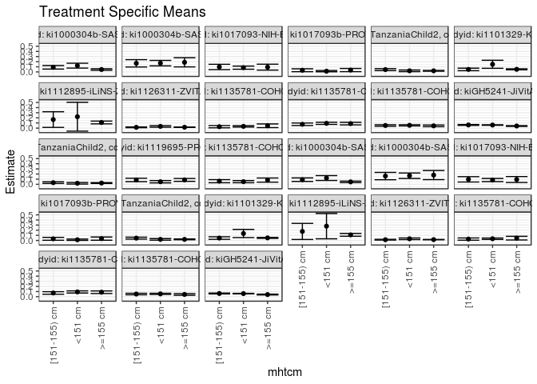

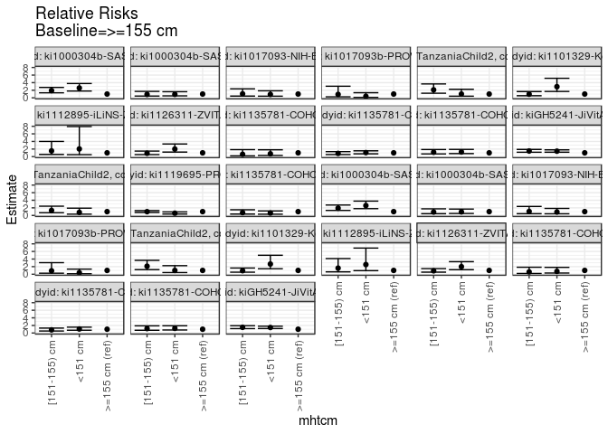

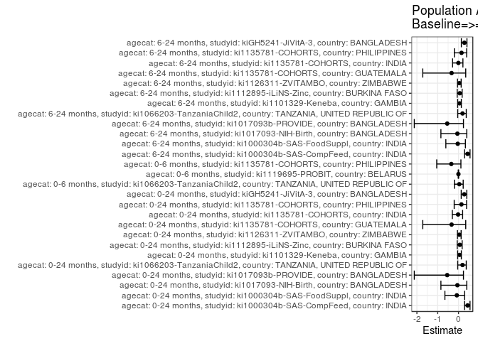

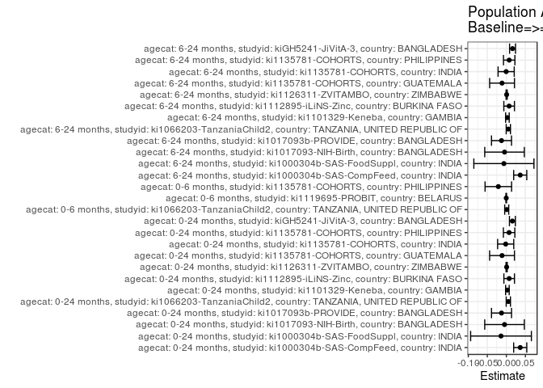

## Results Table

### Parameter: TSM

| agecat | studyid | country | intervention_level | baseline_level | estimate | ci_lower | ci_upper |
| --- | --- | --- | --- | --- | --- | --- | --- |
| 0-24 months | ki1000304b-SAS-CompFeed | INDIA | >=155 cm | NA | 0.0471123 | 0.0322679 | 0.0619567 |
| 0-24 months | ki1000304b-SAS-CompFeed | INDIA | <151 cm | NA | 0.1222257 | 0.0748636 | 0.1695877 |
| 0-24 months | ki1000304b-SAS-CompFeed | INDIA | [151-155) cm | NA | 0.0899304 | 0.0555640 | 0.1242968 |
| 0-24 months | ki1000304b-SAS-FoodSuppl | INDIA | >=155 cm | NA | 0.1873789 | 0.0975411 | 0.2772166 |
| 0-24 months | ki1000304b-SAS-FoodSuppl | INDIA | <151 cm | NA | 0.1712531 | 0.1179774 | 0.2245289 |
| 0-24 months | ki1000304b-SAS-FoodSuppl | INDIA | [151-155) cm | NA | 0.1674149 | 0.0956174 | 0.2392124 |
| 0-24 months | ki1017093-NIH-Birth | BANGLADESH | >=155 cm | NA | 0.0927835 | 0.0349925 | 0.1505745 |
| 0-24 months | ki1017093-NIH-Birth | BANGLADESH | <151 cm | NA | 0.0830671 | 0.0524639 | 0.1136702 |
| 0-24 months | ki1017093-NIH-Birth | BANGLADESH | [151-155) cm | NA | 0.0967742 | 0.0446880 | 0.1488603 |
| 0-24 months | ki1017093b-PROVIDE | BANGLADESH | >=155 cm | NA | 0.0362319 | 0.0050300 | 0.0674337 |
| 0-24 months | ki1017093b-PROVIDE | BANGLADESH | <151 cm | NA | 0.0143678 | 0.0018551 | 0.0268805 |
| 0-24 months | ki1017093b-PROVIDE | BANGLADESH | [151-155) cm | NA | 0.0326797 | 0.0044851 | 0.0608744 |
| 0-24 months | ki1066203-TanzaniaChild2 | TANZANIA, UNITED REPUBLIC OF | >=155 cm | NA | 0.0215613 | 0.0137972 | 0.0293255 |
| 0-24 months | ki1066203-TanzaniaChild2 | TANZANIA, UNITED REPUBLIC OF | <151 cm | NA | 0.0214724 | 0.0057337 | 0.0372111 |
| 0-24 months | ki1066203-TanzaniaChild2 | TANZANIA, UNITED REPUBLIC OF | [151-155) cm | NA | 0.0454545 | 0.0264562 | 0.0644529 |
| 0-24 months | ki1101329-Keneba | GAMBIA | >=155 cm | NA | 0.0506962 | 0.0405591 | 0.0608334 |
| 0-24 months | ki1101329-Keneba | GAMBIA | <151 cm | NA | 0.1488180 | 0.0705434 | 0.2270926 |
| 0-24 months | ki1101329-Keneba | GAMBIA | [151-155) cm | NA | 0.0486168 | 0.0239935 | 0.0732402 |
| 0-24 months | ki1112895-iLiNS-Zinc | BURKINA FASO | >=155 cm | NA | 0.1095894 | 0.0822778 | 0.1369010 |
| 0-24 months | ki1112895-iLiNS-Zinc | BURKINA FASO | <151 cm | NA | 0.2222126 | -0.0587647 | 0.5031899 |
| 0-24 months | ki1112895-iLiNS-Zinc | BURKINA FASO | [151-155) cm | NA | 0.1664781 | 0.0138566 | 0.3190997 |
| 0-24 months | ki1126311-ZVITAMBO | ZIMBABWE | >=155 cm | NA | 0.0167657 | 0.0136150 | 0.0199164 |
| 0-24 months | ki1126311-ZVITAMBO | ZIMBABWE | <151 cm | NA | 0.0335112 | 0.0175573 | 0.0494651 |
| 0-24 months | ki1126311-ZVITAMBO | ZIMBABWE | [151-155) cm | NA | 0.0148260 | 0.0079197 | 0.0217323 |
| 0-24 months | ki1135781-COHORTS | GUATEMALA | >=155 cm | NA | 0.0454545 | 0.0099029 | 0.0810062 |
| 0-24 months | ki1135781-COHORTS | GUATEMALA | <151 cm | NA | 0.0340237 | 0.0203508 | 0.0476966 |
| 0-24 months | ki1135781-COHORTS | GUATEMALA | [151-155) cm | NA | 0.0275229 | 0.0057950 | 0.0492509 |
| 0-24 months | ki1135781-COHORTS | INDIA | >=155 cm | NA | 0.0879949 | 0.0627426 | 0.1132471 |
| 0-24 months | ki1135781-COHORTS | INDIA | <151 cm | NA | 0.0933233 | 0.0720896 | 0.1145571 |
| 0-24 months | ki1135781-COHORTS | INDIA | [151-155) cm | NA | 0.0748509 | 0.0502083 | 0.0994935 |

[output cut: 51 more lines]

### Parameter: E(Y)

| agecat | studyid | country | intervention_level | baseline_level | estimate | ci_lower | ci_upper |
| --- | --- | --- | --- | --- | --- | --- | --- |
| 0-24 months | ki1000304b-SAS-CompFeed | INDIA | NA | NA | 0.0835322 | 0.0594080 | 0.1076564 |
| 0-24 months | ki1000304b-SAS-FoodSuppl | INDIA | NA | NA | 0.1733333 | 0.1349698 | 0.2116969 |
| 0-24 months | ki1017093-NIH-Birth | BANGLADESH | NA | NA | 0.0880150 | 0.0639627 | 0.1120673 |
| 0-24 months | ki1017093b-PROVIDE | BANGLADESH | NA | NA | 0.0234742 | 0.0117259 | 0.0352225 |
| 0-24 months | ki1066203-TanzaniaChild2 | TANZANIA, UNITED REPUBLIC OF | NA | NA | 0.0267229 | 0.0198773 | 0.0335686 |
| 0-24 months | ki1101329-Keneba | GAMBIA | NA | NA | 0.0534138 | 0.0439136 | 0.0629141 |
| 0-24 months | ki1112895-iLiNS-Zinc | BURKINA FASO | NA | NA | 0.1169626 | 0.0922087 | 0.1417166 |
| 0-24 months | ki1126311-ZVITAMBO | ZIMBABWE | NA | NA | 0.0174830 | 0.0146224 | 0.0203435 |
| 0-24 months | ki1135781-COHORTS | GUATEMALA | NA | NA | 0.0341131 | 0.0230006 | 0.0452255 |
| 0-24 months | ki1135781-COHORTS | INDIA | NA | NA | 0.0862385 | 0.0726276 | 0.0998495 |
| 0-24 months | ki1135781-COHORTS | PHILIPPINES | NA | NA | 0.0512273 | 0.0430760 | 0.0593786 |
| 0-24 months | kiGH5241-JiVitA-3 | BANGLADESH | NA | NA | 0.0572397 | 0.0531274 | 0.0613520 |
| 0-6 months | ki1066203-TanzaniaChild2 | TANZANIA, UNITED REPUBLIC OF | NA | NA | 0.0251355 | 0.0183227 | 0.0319484 |
| 0-6 months | ki1119695-PROBIT | BELARUS | NA | NA | 0.0852001 | 0.0575403 | 0.1128599 |
| 0-6 months | ki1135781-COHORTS | PHILIPPINES | NA | NA | 0.0609613 | 0.0448957 | 0.0770269 |
| 6-24 months | ki1000304b-SAS-CompFeed | INDIA | NA | NA | 0.0835322 | 0.0594080 | 0.1076564 |
| 6-24 months | ki1000304b-SAS-FoodSuppl | INDIA | NA | NA | 0.1733333 | 0.1349698 | 0.2116969 |
| 6-24 months | ki1017093-NIH-Birth | BANGLADESH | NA | NA | 0.0880150 | 0.0639627 | 0.1120673 |
| 6-24 months | ki1017093b-PROVIDE | BANGLADESH | NA | NA | 0.0234742 | 0.0117259 | 0.0352225 |
| 6-24 months | ki1066203-TanzaniaChild2 | TANZANIA, UNITED REPUBLIC OF | NA | NA | 0.0267229 | 0.0198773 | 0.0335686 |
| 6-24 months | ki1101329-Keneba | GAMBIA | NA | NA | 0.0534138 | 0.0439136 | 0.0629141 |
| 6-24 months | ki1112895-iLiNS-Zinc | BURKINA FASO | NA | NA | 0.1169626 | 0.0922087 | 0.1417166 |
| 6-24 months | ki1126311-ZVITAMBO | ZIMBABWE | NA | NA | 0.0174830 | 0.0146224 | 0.0203435 |
| 6-24 months | ki1135781-COHORTS | GUATEMALA | NA | NA | 0.0341131 | 0.0230006 | 0.0452255 |
| 6-24 months | ki1135781-COHORTS | INDIA | NA | NA | 0.0862385 | 0.0726276 | 0.0998495 |
| 6-24 months | ki1135781-COHORTS | PHILIPPINES | NA | NA | 0.0512273 | 0.0430760 | 0.0593786 |
| 6-24 months | kiGH5241-JiVitA-3 | BANGLADESH | NA | NA | 0.0572397 | 0.0531274 | 0.0613520 |

### Parameter: RR

| agecat | studyid | country | intervention_level | baseline_level | estimate | ci_lower | ci_upper |
| --- | --- | --- | --- | --- | --- | --- | --- |
| 0-24 months | ki1000304b-SAS-CompFeed | INDIA | >=155 cm | >=155 cm | 1.0000000 | 1.0000000 | 1.0000000 |
| 0-24 months | ki1000304b-SAS-CompFeed | INDIA | <151 cm | >=155 cm | 2.5943485 | 1.7865213 | 3.7674580 |
| 0-24 months | ki1000304b-SAS-CompFeed | INDIA | [151-155) cm | >=155 cm | 1.9088525 | 1.3289744 | 2.7417517 |
| 0-24 months | ki1000304b-SAS-FoodSuppl | INDIA | >=155 cm | >=155 cm | 1.0000000 | 1.0000000 | 1.0000000 |
| 0-24 months | ki1000304b-SAS-FoodSuppl | INDIA | <151 cm | >=155 cm | 0.9139405 | 0.5170901 | 1.6153610 |
| 0-24 months | ki1000304b-SAS-FoodSuppl | INDIA | [151-155) cm | >=155 cm | 0.8934566 | 0.4707808 | 1.6956187 |
| 0-24 months | ki1017093-NIH-Birth | BANGLADESH | >=155 cm | >=155 cm | 1.0000000 | 1.0000000 | 1.0000000 |
| 0-24 months | ki1017093-NIH-Birth | BANGLADESH | <151 cm | >=155 cm | 0.8952787 | 0.4341874 | 1.8460323 |
| 0-24 months | ki1017093-NIH-Birth | BANGLADESH | [151-155) cm | >=155 cm | 1.0430108 | 0.4579132 | 2.3757155 |
| 0-24 months | ki1017093b-PROVIDE | BANGLADESH | >=155 cm | >=155 cm | 1.0000000 | 1.0000000 | 1.0000000 |
| 0-24 months | ki1017093b-PROVIDE | BANGLADESH | <151 cm | >=155 cm | 0.3965517 | 0.1165172 | 1.3496143 |
| 0-24 months | ki1017093b-PROVIDE | BANGLADESH | [151-155) cm | >=155 cm | 0.9019608 | 0.2665520 | 3.0520616 |
| 0-24 months | ki1066203-TanzaniaChild2 | TANZANIA, UNITED REPUBLIC OF | >=155 cm | >=155 cm | 1.0000000 | 1.0000000 | 1.0000000 |
| 0-24 months | ki1066203-TanzaniaChild2 | TANZANIA, UNITED REPUBLIC OF | <151 cm | >=155 cm | 0.9958748 | 0.4400867 | 2.2535709 |
| 0-24 months | ki1066203-TanzaniaChild2 | TANZANIA, UNITED REPUBLIC OF | [151-155) cm | >=155 cm | 2.1081505 | 1.2142426 | 3.6601405 |
| 0-24 months | ki1101329-Keneba | GAMBIA | >=155 cm | >=155 cm | 1.0000000 | 1.0000000 | 1.0000000 |
| 0-24 months | ki1101329-Keneba | GAMBIA | <151 cm | >=155 cm | 2.9354836 | 1.6718773 | 5.1541246 |
| 0-24 months | ki1101329-Keneba | GAMBIA | [151-155) cm | >=155 cm | 0.9589831 | 0.5563129 | 1.6531140 |
| 0-24 months | ki1112895-iLiNS-Zinc | BURKINA FASO | >=155 cm | >=155 cm | 1.0000000 | 1.0000000 | 1.0000000 |
| 0-24 months | ki1112895-iLiNS-Zinc | BURKINA FASO | <151 cm | >=155 cm | 2.0276837 | 0.5188927 | 7.9236063 |
| 0-24 months | ki1112895-iLiNS-Zinc | BURKINA FASO | [151-155) cm | >=155 cm | 1.5191084 | 0.5770413 | 3.9991773 |
| 0-24 months | ki1126311-ZVITAMBO | ZIMBABWE | >=155 cm | >=155 cm | 1.0000000 | 1.0000000 | 1.0000000 |
| 0-24 months | ki1126311-ZVITAMBO | ZIMBABWE | <151 cm | >=155 cm | 1.9987900 | 1.1980758 | 3.3346484 |
| 0-24 months | ki1126311-ZVITAMBO | ZIMBABWE | [151-155) cm | >=155 cm | 0.8843044 | 0.5351755 | 1.4611922 |
| 0-24 months | ki1135781-COHORTS | GUATEMALA | >=155 cm | >=155 cm | 1.0000000 | 1.0000000 | 1.0000000 |
| 0-24 months | ki1135781-COHORTS | GUATEMALA | <151 cm | >=155 cm | 0.7485207 | 0.3106798 | 1.8034108 |
| 0-24 months | ki1135781-COHORTS | GUATEMALA | [151-155) cm | >=155 cm | 0.6055046 | 0.1992921 | 1.8396905 |
| 0-24 months | ki1135781-COHORTS | INDIA | >=155 cm | >=155 cm | 1.0000000 | 1.0000000 | 1.0000000 |
| 0-24 months | ki1135781-COHORTS | INDIA | <151 cm | >=155 cm | 1.0605546 | 0.7353327 | 1.5296150 |
| 0-24 months | ki1135781-COHORTS | INDIA | [151-155) cm | >=155 cm | 0.8506281 | 0.5494515 | 1.3168916 |

[output cut: 51 more lines]

### Parameter: PAR

| agecat | studyid | country | intervention_level | baseline_level | estimate | ci_lower | ci_upper |
| --- | --- | --- | --- | --- | --- | --- | --- |
| 0-24 months | ki1000304b-SAS-CompFeed | INDIA | >=155 cm | NA | 0.0364199 | 0.0192127 | 0.0536272 |
| 0-24 months | ki1000304b-SAS-FoodSuppl | INDIA | >=155 cm | NA | -0.0140455 | -0.0938280 | 0.0657369 |
| 0-24 months | ki1017093-NIH-Birth | BANGLADESH | >=155 cm | NA | -0.0047685 | -0.0567779 | 0.0472409 |
| 0-24 months | ki1017093b-PROVIDE | BANGLADESH | >=155 cm | NA | -0.0127577 | -0.0390460 | 0.0135306 |
| 0-24 months | ki1066203-TanzaniaChild2 | TANZANIA, UNITED REPUBLIC OF | >=155 cm | NA | 0.0051616 | -0.0004171 | 0.0107402 |
| 0-24 months | ki1101329-Keneba | GAMBIA | >=155 cm | NA | 0.0027176 | -0.0020135 | 0.0074487 |
| 0-24 months | ki1112895-iLiNS-Zinc | BURKINA FASO | >=155 cm | NA | 0.0073733 | -0.0065075 | 0.0212541 |
| 0-24 months | ki1126311-ZVITAMBO | ZIMBABWE | >=155 cm | NA | 0.0007172 | -0.0008325 | 0.0022669 |
| 0-24 months | ki1135781-COHORTS | GUATEMALA | >=155 cm | NA | -0.0113415 | -0.0439327 | 0.0212497 |
| 0-24 months | ki1135781-COHORTS | INDIA | >=155 cm | NA | -0.0017563 | -0.0229325 | 0.0194198 |
| 0-24 months | ki1135781-COHORTS | PHILIPPINES | >=155 cm | NA | 0.0072122 | -0.0078084 | 0.0222327 |
| 0-24 months | kiGH5241-JiVitA-3 | BANGLADESH | >=155 cm | NA | 0.0158769 | 0.0081138 | 0.0236399 |
| 0-6 months | ki1066203-TanzaniaChild2 | TANZANIA, UNITED REPUBLIC OF | >=155 cm | NA | 0.0009168 | -0.0043601 | 0.0061936 |
| 0-6 months | ki1119695-PROBIT | BELARUS | >=155 cm | NA | -0.0003428 | -0.0012293 | 0.0005436 |
| 0-6 months | ki1135781-COHORTS | PHILIPPINES | >=155 cm | NA | -0.0210776 | -0.0559082 | 0.0137529 |
| 6-24 months | ki1000304b-SAS-CompFeed | INDIA | >=155 cm | NA | 0.0364199 | 0.0192127 | 0.0536272 |
| 6-24 months | ki1000304b-SAS-FoodSuppl | INDIA | >=155 cm | NA | -0.0065059 | -0.0854403 | 0.0724284 |
| 6-24 months | ki1017093-NIH-Birth | BANGLADESH | >=155 cm | NA | -0.0047685 | -0.0567779 | 0.0472409 |
| 6-24 months | ki1017093b-PROVIDE | BANGLADESH | >=155 cm | NA | -0.0127577 | -0.0390460 | 0.0135306 |
| 6-24 months | ki1066203-TanzaniaChild2 | TANZANIA, UNITED REPUBLIC OF | >=155 cm | NA | 0.0051616 | -0.0004171 | 0.0107402 |
| 6-24 months | ki1101329-Keneba | GAMBIA | >=155 cm | NA | 0.0027215 | -0.0020095 | 0.0074525 |
| 6-24 months | ki1112895-iLiNS-Zinc | BURKINA FASO | >=155 cm | NA | 0.0072874 | -0.0066289 | 0.0212037 |
| 6-24 months | ki1126311-ZVITAMBO | ZIMBABWE | >=155 cm | NA | 0.0007555 | -0.0007923 | 0.0023032 |
| 6-24 months | ki1135781-COHORTS | GUATEMALA | >=155 cm | NA | -0.0113415 | -0.0439327 | 0.0212497 |
| 6-24 months | ki1135781-COHORTS | INDIA | >=155 cm | NA | -0.0005658 | -0.0217889 | 0.0206574 |
| 6-24 months | ki1135781-COHORTS | PHILIPPINES | >=155 cm | NA | 0.0074435 | -0.0075092 | 0.0223963 |
| 6-24 months | kiGH5241-JiVitA-3 | BANGLADESH | >=155 cm | NA | 0.0162305 | 0.0084721 | 0.0239889 |

### Parameter: PAF

| agecat | studyid | country | intervention_level | baseline_level | estimate | ci_lower | ci_upper |
| --- | --- | --- | --- | --- | --- | --- | --- |
| 0-24 months | ki1000304b-SAS-CompFeed | INDIA | >=155 cm | NA | 0.4359988 | 0.2883859 | 0.5529918 |
| 0-24 months | ki1000304b-SAS-FoodSuppl | INDIA | >=155 cm | NA | -0.0810320 | -0.6543148 | 0.2935866 |
| 0-24 months | ki1017093-NIH-Birth | BANGLADESH | >=155 cm | NA | -0.0541785 | -0.8462698 | 0.3980878 |
| 0-24 months | ki1017093b-PROVIDE | BANGLADESH | >=155 cm | NA | -0.5434783 | -2.1252205 | 0.2377097 |
| 0-24 months | ki1066203-TanzaniaChild2 | TANZANIA, UNITED REPUBLIC OF | >=155 cm | NA | 0.1931520 | -0.0377679 | 0.3726886 |
| 0-24 months | ki1101329-Keneba | GAMBIA | >=155 cm | NA | 0.0508782 | -0.0413753 | 0.1349593 |
| 0-24 months | ki1112895-iLiNS-Zinc | BURKINA FASO | >=155 cm | NA | 0.0630395 | -0.0630203 | 0.1741503 |
| 0-24 months | ki1126311-ZVITAMBO | ZIMBABWE | >=155 cm | NA | 0.0410240 | -0.0515736 | 0.1254677 |
| 0-24 months | ki1135781-COHORTS | GUATEMALA | >=155 cm | NA | -0.3324675 | -1.7178844 | 0.3467457 |
| 0-24 months | ki1135781-COHORTS | INDIA | >=155 cm | NA | -0.0203659 | -0.2979840 | 0.1978741 |
| 0-24 months | ki1135781-COHORTS | PHILIPPINES | >=155 cm | NA | 0.1407875 | -0.2075648 | 0.3886489 |
| 0-24 months | kiGH5241-JiVitA-3 | BANGLADESH | >=155 cm | NA | 0.2773754 | 0.1303632 | 0.3995352 |
| 0-6 months | ki1066203-TanzaniaChild2 | TANZANIA, UNITED REPUBLIC OF | >=155 cm | NA | 0.0364737 | -0.1978128 | 0.2249348 |
| 0-6 months | ki1119695-PROBIT | BELARUS | >=155 cm | NA | -0.0040239 | -0.0144319 | 0.0062773 |
| 0-6 months | ki1135781-COHORTS | PHILIPPINES | >=155 cm | NA | -0.3457544 | -1.0468233 | 0.1151874 |
| 6-24 months | ki1000304b-SAS-CompFeed | INDIA | >=155 cm | NA | 0.4359988 | 0.2883859 | 0.5529918 |
| 6-24 months | ki1000304b-SAS-FoodSuppl | INDIA | >=155 cm | NA | -0.0375341 | -0.6089343 | 0.3309379 |
| 6-24 months | ki1017093-NIH-Birth | BANGLADESH | >=155 cm | NA | -0.0541785 | -0.8462698 | 0.3980878 |
| 6-24 months | ki1017093b-PROVIDE | BANGLADESH | >=155 cm | NA | -0.5434783 | -2.1252205 | 0.2377097 |
| 6-24 months | ki1066203-TanzaniaChild2 | TANZANIA, UNITED REPUBLIC OF | >=155 cm | NA | 0.1931520 | -0.0377679 | 0.3726886 |
| 6-24 months | ki1101329-Keneba | GAMBIA | >=155 cm | NA | 0.0509517 | -0.0413121 | 0.1350405 |
| 6-24 months | ki1112895-iLiNS-Zinc | BURKINA FASO | >=155 cm | NA | 0.0623052 | -0.0641109 | 0.1737031 |
| 6-24 months | ki1126311-ZVITAMBO | ZIMBABWE | >=155 cm | NA | 0.0432110 | -0.0492582 | 0.1275311 |
| 6-24 months | ki1135781-COHORTS | GUATEMALA | >=155 cm | NA | -0.3324675 | -1.7178844 | 0.3467457 |
| 6-24 months | ki1135781-COHORTS | INDIA | >=155 cm | NA | -0.0065604 | -0.2853451 | 0.2117573 |
| 6-24 months | ki1135781-COHORTS | PHILIPPINES | >=155 cm | NA | 0.1453042 | -0.2014532 | 0.3919822 |
| 6-24 months | kiGH5241-JiVitA-3 | BANGLADESH | >=155 cm | NA | 0.2835535 | 0.1365244 | 0.4055471 |